# Programlamanın Temelleri

# 1 Programlamanın Temelleri

Bu derste R ile çalışmamızın en önemli nedeni, R’ın veri analizini büyük ölçüde kolaylaştırıyor oluşudur.

R kullanarak verimli bir şekilde veri analizi yapabilir, veri analizi boru hatları (pipelines %>% ) oluşturabilir ve analiz sonuçlarımızı paylaşmak için veri görselleştirmesi ile raporlar hazırlayabiliriz.

R ilk derste de bahsedildiği üzere sadece bir veri analiz ortamı değil, aynı zamanda bir programlama dilidir.

Gelişmiş R programcıları karmaşık paketler (packages) geliştirebilir.

Bu derste R ile paket geliştirme konusuna girmeden üç temel programlama kavramını üzerinde duracağız: fonksiyonlar, koşullu ifadeler ve for döngüleri.

Bu kavramlar gelişmiş programlama için temel yapı taşları olmanın yanı sıra, zaman zaman veri analizi yaparken de kullanışlı olabilecek kavramlardır.

**Derse başlamadan önce gerekli paketlerin kurulumunu gerçekleştirelim.**

```r
install.packages("dslabs")
install.packages("here")
```

```r
library(tidyverse)
library(dslabs)
library(here)
```

# 2 Fonksiyonlar

R konusunda daha tecrübeli hale geldiğinizde, aynı işlemleri tekrar tekrar yapmaya için ihtiyaç duyduğunuzu göreceksiniz.

Buna en basit örnek ortalama hesaplamak olabilir.

$$\text{Ortalama} = \frac{1}{n}\sum_{i = 1}^n x_i$$

Bir `x` sayısal vektörünün ortalamasını nasıl hesaplayabiliriz?

```r
x <- rnorm(10)
x
```

```
##  [1] -0.9208402 -0.1965494  0.7446885 -1.2327736 -0.6407436  0.3201082
##  [7]  1.6423812  0.9410328  0.2065958  0.1850692
```

`sum` ve `length` fonksiyonlarını kullanarak bulabiliriz: `sum(x)/length(x)`.

Bu işlemi sıklıkla yapıyorsak her seferinde `sum(x)/length(x)` yazmaktansa bunu bir fonksiyon haline getirebiliriz.

Bu R’da bizim için zaten yazılmış bir fonksiyondur: `mean`.

Fakat bazı durumlarda hiç kimsenin daha önce yazmadığı türden fonksiyonlar yazmamız gerekebilir.

Bahsettiğimiz ortalama fonksiyonu R’da basitçe şu şekide yazılır:

```r
avg <- function(x) {
  s <- sum(x)
  n <- length(x)
  s / n
}
```

`avg()` bir sayısal vektör alan ve sonuçta bize o vektörün ortalamasını veren bir fonksiyondur:

```r
x <- 1:100
identical(mean(x), avg(x))
```

```
## [1] TRUE
```

Bir fonksiyon içinde tanımlanan değişkenlerin çalışma alanına kaydedilmediğine dikkat edin.

`avg` fonksiyonunu kullandığımızda `s` ve `n` değişkenlerini kullanırız fakat bu değişkenler fonksiyon içinde yaratılır ve değerleri atanır.

Bu değişkenler çalışma alanımıza kaydedilmezler.

```r
s <- 3
avg(1:10)
```

```
## [1] 5.5
```

```r
s
```

```
## [1] 3
```

`avg` fonksiyonunu kullandıktan sonra `s`’nin halen daha 3 olduğuna dikkat edin.

Fonksiyonlar da genellikle R objeleridirler ve `<-` kullanılarak değişken isimleri atanır.

Fonksiyon yazarken kullandığımız `function` komutu R’a bir fonksiyon tanımlamaya başladığımız bilgisini verir.

Tanımladığımız fonksiyonlar birden fazla girdi ile çalışabilecekleri gibi bazı varsayılan değerlere de sahip olabilirler.

Örneğin, kullanıcı tarafından tanımlanan bir değişken ile aritmetik veya geometrik ortalama hesaplayan bir fonksiyon yazabiliriz.

Geometrik ortalama formülünün

$$\text{Geometrik Ortalama} = \left(\prod_{i=1}^n x_i \right)^\frac{1}{n}$$

olduğunu hatırlayın.

Aritmetik veya geometrik ortalama hesaplayan fonksiyonumuzu aşağıdaki biçimde yazabiliriz.

```r
avg <- function(x, arithmetic = TRUE) {
  n <- length(x)
  ifelse(arithmetic, sum(x) / n, prod(x)^(1 / n))
}

(x <- 1:10)
```

```
##  [1]  1  2  3  4  5  6  7  8  9 10
```

```r
avg(x, arithmetic = TRUE)
```

```
## [1] 5.5
```

```r
avg(x, arithmetic = FALSE)
```

```
## [1] 4.528729
```

`if-else` konusunda bu örneği tekrar inceleyeceğiz.

Fonksiyonlar birden fazla argümana sahip olabilirler.

```r
mysum <- function(x, y) {
  z <- x + y
  z
}

mysum(2, 3)
```

```
## [1] 5
```

### 2.0.1 Quiz 1

```r
f1 <- function(string, prefix) {
  substr(string, 1, nchar(prefix)) == prefix
}
```

```r
?substr
?nchar
```

```r
f1("Mülkiye", "M")
f1("Mülkiye", "S")
```

CEVAP

### 2.0.2 Quiz 2

```r
f2 <- function(x, y) {
  z <- x^y / x*y
  z
}
```

```r
f2(3, 4)
f2(c(1, 2, 3), 2)
```

CEVAP

# 3 Koşullu İfadeler

Koşullu ifadeler, programlamanın temel özelliklerinden biridir.

En yaygın koşullu ifade komutu `if-else` (eğer - ise)’tir.

R’da, koşullu ifadeleri kullanmadan bir çok veri analizi yapabiliriz.

Ancak, koşullu ifadeler zaman zaman karşımıza çıkarlar.

Kendi fonksiyonlarımızı ve paketlerimizi yazmaya başladığımızda, koşullu ifadelere kesinlikle ihtiyacımız olacaktır.

Aşağıdaki komut `if-else` koşullu ifadesine temel bir örnektir.

Burada ana düşünce `a` sıfırdan farklı bir sayı olduğunda `a`’nın tersini ekrana yazdırmaktır.

```r
a <- 0

if (a != 0) {
  print(1 / a)
} else {
  print("0'ın tersi yoktur.")
}
```

```
## [1] "0'ın tersi yoktur."
```

`a` sıfırdan farklı ise:

```r
a <- 2

if (a != 0) {
  print(1 / a)
} else {
  print("0'ın tersi yoktur.")
}
```

```
## [1] 0.5
```

Öğrenci performansı verisini içeren veri setini internetten indirelim ve veri setine göz atalım.

```r
students <- read.delim("https://bit.ly/2C5EXWA", sep = ";")
students
```

```
##     school sex age address famsize Pstatus Medu Fedu     Mjob     Fjob
## 1       GP   F  18       U     GT3       A    4    4  at_home  teacher
## 2       GP   F  17       U     GT3       T    1    1  at_home    other
## 3       GP   F  15       U     LE3       T    1    1  at_home    other
## 4       GP   F  15       U     GT3       T    4    2   health services
## 5       GP   F  16       U     GT3       T    3    3    other    other
## 6       GP   M  16       U     LE3       T    4    3 services    other
## 7       GP   M  16       U     LE3       T    2    2    other    other
## 8       GP   F  17       U     GT3       A    4    4    other  teacher
## 9       GP   M  15       U     LE3       A    3    2 services    other
## 10      GP   M  15       U     GT3       T    3    4    other    other
## 11      GP   F  15       U     GT3       T    4    4  teacher   health
## 12      GP   F  15       U     GT3       T    2    1 services    other
## 13      GP   M  15       U     LE3       T    4    4   health services
## 14      GP   M  15       U     GT3       T    4    3  teacher    other
```

[output cut: 1569 more lines]

Veri setinde yer alan **G3** değişkeni, öğrencinin final notunu göstermektedir.

`if-else` koşullu ifadesini kullanarak öğrencilerin harf notlarını atamak mümkündür.

Bir önceki bölümde öğrendiğimiz fonksiyonları da kullanarak öğrencilerin final notlarına göre harf notlarını atayan bir fonksiyon yazabiliriz.

```r
calculateLetterGrade <- function(x) {
  if (x >= 18) {
    grade <- "A"
  } else if (x >= 16) {
    grade <- "B"
  } else if (x >= 14) {
    grade <- "C"
  } else {
    grade <- "F"
  }
  grade
}


calculateLetterGrade(students$G3)
```

```
## [1] "F"
```

Fonksiyonda tanımlı x girdisi tek bir sayıdır ve bu nedenle fonksiyonumuz sadece ilk öğrencinin harf notunu ekrana yazdırmıştır.

Tüm öğrencilerin harf notlarını hesaplamak için fonksiyonu veri setinin her bir satırına tek tek uygulamamız gerekir.

Bunu yapmanın farklı yolları vardır.

```r
students$LetterGrade <- sapply(students$G3, calculateLetterGrade)
```

```r
students <- students %>%
  rowwise() %>%
  mutate(LetterGrade = calculateLetterGrade(G3))

students %>%
  select(G3, LetterGrade) %>%
  glimpse()
```

```
## Rows: 395
## Columns: 2
## Rowwise:
## $ G3          <int> 6, 6, 10, 15, 10, 15, 11, 6, 19, 15, 9, 12, 14, 11, 16, 14…
## $ LetterGrade <chr> "F", "F", "F", "C", "F", "C", "F", "F", "A", "C", "F", "F"…
```

`if-else` koşullu ifadesi ile ilişkili diğer faydalı bir fonksiyon da `ifelse`’tir.

Bu fonksiyon 3 farklı argüman alır: 1 mantıksal ve 2 olası cevap.

Eğer mantıksal koşul doğru (`TRUE`) ise ilk cevap, eğer yanlış ise (`FALSE`) ikinci cevap fonksiyon tarafından döndürülür.

İlk bölümdeki örneğimize dönersek:

```r
avg <- function(x, arithmetic = TRUE) {
  n <- length(x)
  ifelse(arithmetic, sum(x) / n, prod(x)^(1 / n))
}
```

Burada eğer kullanıcı fonksiyonda `arithmetic = TRUE` tanımlamışsa, `ifelse`’in ilk argümanı doğrudur.

Bu durumda fonksiyon ilk olası cevabı yani aritmetik ortalamayı verir.

`arithmetic = FALSE` olarak tanımlandığında ise fonksiyon geometrik ortalamayı verecektir.

```r
(x <- 1:10)
```

```
##  [1]  1  2  3  4  5  6  7  8  9 10
```

```r
avg(x, arithmetic = TRUE)
```

```
## [1] 5.5
```

```r
avg(x, arithmetic = FALSE)
```

```
## [1] 4.528729
```

`ifelse`’in diğer bir avantajı da vektörler üzerinde işlem yapabiliyor olmasıdır.

Bu fonksiyonun vektörün her bir elemanı üzerine mantıksal sınamayı yaptığı ve her eleman için cevabı verdiği anlamına gelir.

Örneğin:

```r
a <- c(0, 1 ,2, -4, 5)
a
```

```
## [1]  0  1  2 -4  5
```

```r
result <- ifelse(a > 0, 1/a, NA)
result
```

```
## [1]  NA 1.0 0.5  NA 0.2
```

Burada `ifelse` fonksiyonu `a` vektörünün her elemanının sıfıdan büyük olup olmadığını test etmiş, büyük olduğu durumlarda tersini almış, olmadığı durumlarda ise `NA` değerini atamıştır.

Aşağıda yer alan tablo fonksiyonun ne yaptığını özetlemektedir:

```r
knitr::kable(data.frame(a = a,
                        Mantıkİşlemi = a > 0,
                        Cevap1 = 1/a,
                        Cevap2 = NA,
                        Sonuç = result))
```

| a | Mantıkİşlemi | Cevap1 | Cevap2 | Sonuç |
| --- | --- | --- | --- | --- |
| 0 | FALSE | Inf | NA | NA |
| 1 | TRUE | 1.00 | NA | 1.0 |
| 2 | TRUE | 0.50 | NA | 0.5 |
| -4 | FALSE | -0.25 | NA | NA |
| 5 | TRUE | 0.20 | NA | 0.2 |

Bu fonksiyonun veri analizinde kullanımına güzel bir örnek olarak bir vektördeki tüm eksik gözlemleri sıfır ile değiştirme işlemi verilebilir:

```r
data(na_example) # dslabs paketi içerisinde örnek veri seti
head(na_example, 35)
```

```
##  [1]  2  1  3  2  1  3  1  4  3  2  2 NA  2  2  1  4 NA  1  1  2  1  2  2  1  2
## [26]  5 NA  2  2  3  1  2  4  1  1
```

```r
head(is.na(na_example), 35)
```

```
##  [1] FALSE FALSE FALSE FALSE FALSE FALSE FALSE FALSE FALSE FALSE FALSE  TRUE
## [13] FALSE FALSE FALSE FALSE  TRUE FALSE FALSE FALSE FALSE FALSE FALSE FALSE
## [25] FALSE FALSE  TRUE FALSE FALSE FALSE FALSE FALSE FALSE FALSE FALSE
```

```r
sum(is.na(na_example))
```

```
## [1] 145
```

```r
na_example <- ifelse(is.na(na_example), 0, na_example)
head(na_example, 35)
```

```
##  [1] 2 1 3 2 1 3 1 4 3 2 2 0 2 2 1 4 0 1 1 2 1 2 2 1 2 5 0 2 2 3 1 2 4 1 1
```

```r
head(is.na(na_example), 35)
```

```
##  [1] FALSE FALSE FALSE FALSE FALSE FALSE FALSE FALSE FALSE FALSE FALSE FALSE
## [13] FALSE FALSE FALSE FALSE FALSE FALSE FALSE FALSE FALSE FALSE FALSE FALSE
## [25] FALSE FALSE FALSE FALSE FALSE FALSE FALSE FALSE FALSE FALSE FALSE
```

```r
sum(is.na(na_example))
```

```
## [1] 0
```

### 3.0.1 Quiz 1 Cevap

```r
f1("Mülkiye", "M")
```

```
## [1] TRUE
```

```r
f1("Mülkiye", "S")
```

```
## [1] FALSE
```

Quiz 1

# 4 For (için) döngüsü

$1+2+\dots+n$ toplamı için kullanılacak formül $\frac{n(n+1)}{2}$’dir.

Bunun doğru formül olduğundan emin değilsek, bu toplamı nasıl kontrol edebiliriz?

Fonksiyonlar hakkında öğrendiklerimizi uygulayarak $S_n$ toplamını hesaplayan bir fonksiyon yazabiliriz.

```r
compute_s_n <- function(n) {
  x <- 1:n
  sum(x)
}
```

Fonksiyonumuzu yazdıktan sonra farklı $n$ değerleri için, örneğin $n=1,\dots,25$, $S_n$’i hesaplayabiliriz.

Bunu 25 satır kod yazıp, her $n$ değeri için `compute_s_n` fonksiyonunu çalıştırarak yapmak mantıklı değildir.

```r
compute_s_n(1)
```

```
## [1] 1
```

```r
compute_s_n(2)
```

```
## [1] 3
```

```r
# ...
compute_s_n(24)
```

```
## [1] 300
```

```r
compute_s_n(25)
```

```
## [1] 325
```

Programlamada döngüler bu gibi durumlarda kullanılır.

$n$’in değerini değiştirirerek aynı işlemi tekrar tekrar yapmaktansa `for` döngüsü yazabiliriz.

`for` döngüsü değişkenimiz için bir aralık tanımlamamıza, örneğin $n=1,\dots,10$, ve bu değerleri döngü içerisinde kullanıp işlemi yapmamıza olanak tanır.

`for` döngüsü en basit haliye şu şekilde yazılabilir:

```r
for (i in 1:5) {
  print(i)
}
```

```
## [1] 1
## [1] 2
## [1] 3
## [1] 4
## [1] 5
```

$S_n$ örneği için ise döngü şu şekilde olacaktır:

```r
m <- 25
s_n <- vector(length = m) # Uzunluğu m olan boş bir vektör yaratıyoruz
for (n in 1:m) {
  s_n[n] <- compute_s_n(n)
}
head(s_n)
```

```
## [1]  1  3  6 10 15 21
```

Her bir tekrarlamada (iteration), yani $n=1$, $n=2$, vs. olduğunda, $S_n$ değerini hesaplıyor ve hesaplanan değeri `s_n` vektörünün $n$inci elemanına kaydediyoruz.

Şimdi formülün doğruluğunu test etmek için bir grafik çizebilir ve toplamın herhangi bir kalıba uyup uymadığına bakabiliriz.

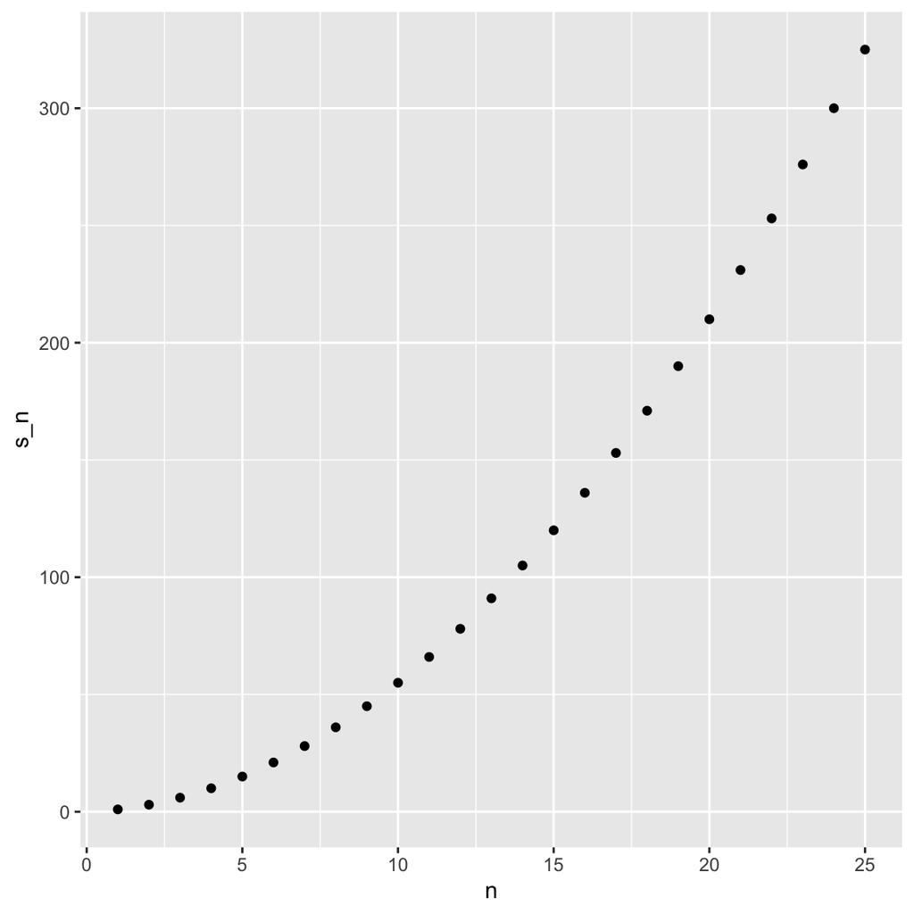

```r
dt <- tibble(n = 1:m,
             s_n = s_n)
dt %>%
  ggplot(aes(x = n, y = s_n)) +
  geom_point()
```

Grafikten görüldüğü üzere karesel (quadratic) bir kalıp gözlemlenmektedir.

Bu doğru yolda olduğumuzu gösterir çünkü test etmeye çalıştığımız formül $\frac{n(n+1)}{2}$ idi.

Bunu bir tablo yaratarak da doğrulayabiliriz:

```r
# N       -> 1, 2, 3, ... , 25
# S_n     -> 1, 3, 6, ..., 325
# formula -> 1, 3, 6, ..., 325
dt_formula <- tibble(N = 1:m,
                     S_n = s_n,
                     formula = N * (N + 1) / 2)

knitr::kable(rbind(head(dt_formula, 5), tail(dt_formula, 5)))
```

| N | S_n | formula |
| --- | --- | --- |
| 1 | 1 | 1 |
| 2 | 3 | 3 |
| 3 | 6 | 6 |
| 4 | 10 | 10 |
| 5 | 15 | 15 |
| 21 | 231 | 231 |
| 22 | 253 | 253 |
| 23 | 276 | 276 |
| 24 | 300 | 300 |
| 25 | 325 | 325 |

# 5 While (iken) döngüsü

İken döngüleri, belirli bir koşul sağlanana kadar devam eden döngü oluşturmak için kullanılır.

```r
i <- 1
while (i < 6) {
  print(i)
  i <- i + 1
}
```

```
## [1] 1
## [1] 2
## [1] 3
## [1] 4
## [1] 5
```

R, döngü içerisindeki koşulu mantıksal olmaya zorlar ve bunun tek bir mantıksal değer olmasını bekler.

Koşul mantıksal bir vektörse, ilk eleman kullanılacak ve bir uyarı verilecektir.

Ayrıca, döngü iyi belirtilmezse sonsuza kadar çalıştırılabilir (sonsuz döngü).

```r
x <- 1
while (x > 0) {
  x <- x + 1
  print(x)
}
```

Sonsuz döngüden **Ctrl + C** ile çıkabilirsiniz.

### 5.0.1 Quiz 2 Cevap

```r
f2(3, 4)
```

```
## [1] 108
```

```r
f2(c(1, 2, 3), 2)
```

```
## [1] 2 4 6
```

Quiz 2

# 6 next, break ve return

- `break`: döngüyü durdurur.

```r
x <- c(-3.5, 10.3, -3.2, 1.2, -10.3, 20,3)

for (i in 1:length(x)) {
  if (x[i] < 0) {
    break
  }
  print(x[i])
}
```

- `next`: iterasyonu atlar ve döngüye devam eder.

```r
x <- c(-3.5, -10.3, -3.2, -1.2, -10.3, -20, -3)

for (i in 1:length(x)) {
    # Eğer x[i] negatif ise bu iterasyonu atla
    # bir sonraki iterasyona geç ('i')
    if (x[i] < 0) {
        next
    }
    # Eğer x[i] pozitif ise yazdır
    print(x[i])
}
```

- `return()`: döngüler fonksiyon içerisinde ise bir sonucu göstermeye yarar.

```r
tekleri_say <- function(x) {
  check <- x %% 2 != 0
  return(sum(check, na.rm = TRUE))
}

x <- 1:3
x
```

```
## [1] 1 2 3
```

```r
tekleri_say(x)
```

```
## [1] 2
```

# 7 Repeat (tekrarla) döngüsü

Repeat döngüsü açık bir şekilde `break` tanımlanmadıkça verilen komutları tekrarlamaya devam eder.

```r
x <- 0
repeat {
  # x^2, 20'den büyük ise döngüyü bitir
  if (x^2 > 20) break
  # x^2 <= 20 ise x'i ekrana yazdır ve 1 artırarak devam et
  print(x)
  x <- x + 1
}
```

```
## [1] 0
## [1] 1
## [1] 2
## [1] 3
## [1] 4
```

# 8 Fonksiyonel Programlama

Diğer programlama dillerinin aksine **döngüler R’da çok da önemli değildir**.

Bunun nedeni R dilinin bir fonksiyonel programlama dili olmasından kaynaklanır.

Bu ise döngülerin fonksiyonlar içerisine yerleştirilebileceği ve döngüleri tekrar tekrar yazmaktansa fonksiyonu doğrudan kullanabileceğimiz anlamına gelir.

```r
set.seed(2020)
df <- tibble(
  a = rnorm(10),
  b = rnorm(10),
  c = rnorm(10),
  d = rnorm(10)
)

df
```

```
## # A tibble: 10 × 4
##         a       b       c       d
##     <dbl>   <dbl>   <dbl>   <dbl>
##  1  0.377 -0.853   2.17   -0.813
##  2  0.302  0.909   1.10   -0.744
##  3 -1.10   1.20    0.318   1.10
##  4 -1.13  -0.372  -0.0731  2.44
##  5 -2.80  -0.123   0.834   0.388
##  6  0.721  1.80    0.199   0.291
##  7  0.939  1.70    1.30   -0.286
##  8 -0.229 -3.04    0.937   0.0760
##  9  1.76  -2.29   -0.147  -0.560
## 10  0.117  0.0583  0.110   0.447
```

gibi bir veri setimiz olduğunu ve her bir sütun için ortalama hesaplamak istediğimizi varsayalım.

For döngüsü kullanarak bu işlemi

```r
output <- vector("double", length(df))
for (i in seq_along(df)) {
  output[[i]] <- mean(df[[i]])
}
output
```

```
## [1] -0.1039628 -0.1007732  0.6748199  0.2330564
```

şeklinde gerçekleştirebiliriz.

Eğer bu döngüyü sıklıkla kullanacaksak bunu bir fonksiyon haline getirmemiz mümkündür.

Bu şekilde her seferinde bu döngüyü tekrar yazmamız gerekmez.

```r
col_mean <- function(df) {
  output <- vector("double", length(df))
  for (i in seq_along(df)) {
    output[i] <- mean(df[[i]])
  }
  output
}
```

```r
col_mean(df)
```

```
## [1] -0.1039628 -0.1007732  0.6748199  0.2330564
```

Şimdi de her bir sütun için ortalama yanında medyan ve standart sapma bilgisini de hesaplamak istediğimizi varsayalım.

Bunun için de tekrar tekrar fonksiyon yazmaktansa yukarıda yazdığımız fonksiyonu genelleştirebiliriz.

```r
col_summary <- function(df, fun) {
  out <- vector("double", length(df))
  for (i in seq_along(df)) {
    out[i] <- fun(df[[i]])
  }
  out
}
```

Bu fonksiyon tekrar tekrar döngü ve fonksiyon yazmamıza gerek kalmadan bir veri seti üzerinde farklı hesaplamalar yapmamıza imkan tanır.

```r
col_summary(df, mean)
```

```
## [1] -0.1039628 -0.1007732  0.6748199  0.2330564
```

```r
col_summary(df, median)
```

```
## [1]  0.20945758 -0.03247837  0.57624453  0.18332119
```

```r
col_summary(df, sd)
```

```
## [1] 1.290613 1.621325 0.731660 0.979642
```

Aynı fonksiyonu bu sefer satır işlemleri için yazmak istediğimizi varsayalım.

Her bir sütunun değil de her bir satırın ortalama, medyan ve standart sapmasını hesaplamak için bir fonksiyon yazalım.

```r
row_summary <- function(df, fun) {
  out <- vector("double", nrow(df))
  for (i in 1:nrow(df)) {
    x <- unlist(df[i,])
    out[i] <- fun(x)
  }
  out
}
```

```r
row_summary(df, mean)
```

```
##  [1]  0.2214275  0.3913220  0.3779788  0.2150591 -0.4243518  0.7524987
##  [7]  0.9138400 -0.5638523 -0.3093939  0.1833227
```

```r
row_summary(df, median)
```

```
##  [1] -0.21776627  0.60540378  0.70678270 -0.22236573  0.13242912  0.50560058
##  [7]  1.11848120 -0.07668151 -0.35386590  0.11389939
```

```r
row_summary(df, sd)
```

```
##  [1] 1.4214821 0.8295079 1.0593294 1.5456699 1.6291245 0.7344681 0.8585054
##  [8] 1.7222278 1.6619990 0.1778746
```

# 9 `map` Fonksiyonları

`purrr` paketi içerisinde yer alan fonksiyonlar bir vektör üzerinde döngü kurmak, her bir eleman üzerinde işlem gerçekleştirmek ve sonuçları kaydetmek için kullanılabilir.

Her bir çıktı türü için `purrr` paketinde özel bir fonksiyon yer almaktadır.

- `map()` liste oluşturur
- `map_lgl()` mantıksal vektör oluşturur
- `map_int()` tam sayı vektörü oluşturur
- `map_dbl()` sayı vektörü oluşturur
- `map_chr()` karakter vektörü oluşturur

Bu fonksiyonları kullanarak döngüler ile yaptığımız iterasyon (yineleme, tekrarlama) işlemlerini kolaylıkla gerçekleştirebiliriz.

```r
df
```

```
## # A tibble: 10 × 4
##         a       b       c       d
##     <dbl>   <dbl>   <dbl>   <dbl>
##  1  0.377 -0.853   2.17   -0.813
##  2  0.302  0.909   1.10   -0.744
##  3 -1.10   1.20    0.318   1.10
##  4 -1.13  -0.372  -0.0731  2.44
##  5 -2.80  -0.123   0.834   0.388
##  6  0.721  1.80    0.199   0.291
##  7  0.939  1.70    1.30   -0.286
##  8 -0.229 -3.04    0.937   0.0760
##  9  1.76  -2.29   -0.147  -0.560
## 10  0.117  0.0583  0.110   0.447
```

```r
purrr::map_dbl(df, mean)
```

```
##          a          b          c          d
## -0.1039628 -0.1007732  0.6748199  0.2330564
```

```r
purrr::map_dbl(df, median)
```

```
##           a           b           c           d
##  0.20945758 -0.03247837  0.57624453  0.18332119
```

```r
purrr::map_dbl(df, sd)
```

```
##        a        b        c        d
## 1.290613 1.621325 0.731660 0.979642
```

```r
x <- list(1:10, 20:40, c(rep(NA, 4), -10:10))
x
```

```
## [[1]]
##  [1]  1  2  3  4  5  6  7  8  9 10
##
## [[2]]
##  [1] 20 21 22 23 24 25 26 27 28 29 30 31 32 33 34 35 36 37 38 39 40
##
## [[3]]
##  [1]  NA  NA  NA  NA -10  -9  -8  -7  -6  -5  -4  -3  -2  -1   0   1   2   3   4
## [20]   5   6   7   8   9  10
```

```r
y <- purrr::map(x, ~var(.x, na.rm = TRUE))
is.list(y)
```

```
## [1] TRUE
```

```r
y
```

```
## [[1]]
## [1] 9.166667
##
## [[2]]
## [1] 38.5
##
## [[3]]
## [1] 38.5
```

```r
unlist(y)
```

```
## [1]  9.166667 38.500000 38.500000
```

`map_*()` fonksiyonları hakkında şimdilik bu kadar bilgi yeterlidir.

`map2()` fonksiyonlarını kullanarak çoklu girdiler kullanmak da mümkündür.

```r
x <- list(1, 1, 1)
y <- list(10, 20, 30)

purrr::map2(x, y, ~ .x + .y)
```

```
## [[1]]
## [1] 11
##
## [[2]]
## [1] 21
##
## [[3]]
## [1] 31
```

```r
ex_fun <- function(arg1, arg2){
  col <- arg1 + arg2
  x <- tibble::tibble(mysum = col)
}

arg1 <- 1:4
arg2 <- 10:13

purrr::map2_dfr(arg1, arg2, ex_fun)
```

```
## # A tibble: 4 × 1
##   mysum
##   <int>
## 1    11
## 2    13
## 3    15
## 4    17
```